# College Admission Prediction

Deo Ivan Mareza

`14 February 2020`

# INTRODUCTION

In this exercise, I want to predict someone’s `chance of admission` to a university of their choice using linear regression method based on other variables.  
I will use MSE and RMSE as a measure of my model’s accuracy.

# DATA PREPARATION

Library packages that I’m using

```r
library(tidyverse)
library(GGally)
library(MLmetrics)
library(car)
library(lmtest)
library(stringr)
```

Reading the data

```r
admission <- read_csv("data_input/Admission_Predict_Ver1.1.csv")
```

Checking the data

```r
knitr::kable(head(admission, 10))
```

| Serial No. | GRE Score | TOEFL Score | University Rating | SOP | LOR | CGPA | Research | Chance of Admit |
| --- | --- | --- | --- | --- | --- | --- | --- | --- |
| 1 | 337 | 118 | 4 | 4.5 | 4.5 | 9.65 | 1 | 0.92 |
| 2 | 324 | 107 | 4 | 4.0 | 4.5 | 8.87 | 1 | 0.76 |
| 3 | 316 | 104 | 3 | 3.0 | 3.5 | 8.00 | 1 | 0.72 |
| 4 | 322 | 110 | 3 | 3.5 | 2.5 | 8.67 | 1 | 0.80 |
| 5 | 314 | 103 | 2 | 2.0 | 3.0 | 8.21 | 0 | 0.65 |
| 6 | 330 | 115 | 5 | 4.5 | 3.0 | 9.34 | 1 | 0.90 |
| 7 | 321 | 109 | 3 | 3.0 | 4.0 | 8.20 | 1 | 0.75 |
| 8 | 308 | 101 | 2 | 3.0 | 4.0 | 7.90 | 0 | 0.68 |
| 9 | 302 | 102 | 1 | 2.0 | 1.5 | 8.00 | 0 | 0.50 |
| 10 | 323 | 108 | 3 | 3.5 | 3.0 | 8.60 | 0 | 0.45 |

The Data Explains :  
1. GRE Scores ( out of 340 )  
2. TOEFL Scores ( out of 120 )  
3. University Rating ( out of 5 )  
4. Statement of Purpose and Letter of Recommendation Strength ( out of 5 )  
5. Undergraduate GPA ( out of 10 )  
6. Research Experience ( either 0 or 1 )  
7. Chance of Admit ( ranging from 0 to 1 )

I’m changing the column names to something more code-friendly & our research column from numeric to a logical TRUE and FALSE

```r
names(admission) <- str_replace_all(str_to_lower(names(admission)), " ", "_")
admission[,"research"] <- as.logical(as.integer( unlist(admission[,"research"])))
```

## Separating Data to Train and Test

```r
admission_train <- admission[1:400,]
admission_test <- admission[401:ncol(admission),]
```

# DATA ANALYSIS

Checking if any of the variables are linearly related to each other.

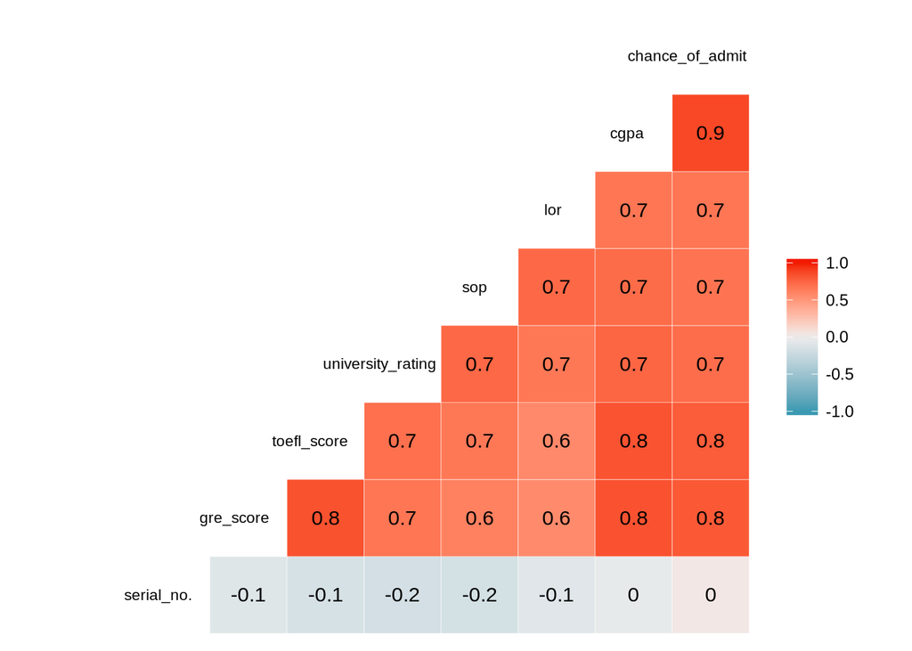

```r
ggcorr(admission_train, label = T, hjust = .7, layout.exp = 1, label_size = 4, cex = 3)
```

Seeing that all variablers have a good correlation with each other except the serial number, I think we can move to modelling and exclude the serial number in our model.

# MODELLING

I’ll make a linear model with the name `model_admission`

```r
model_admission <- lm(formula = chance_of_admit ~ gre_score + toefl_score +
    university_rating + lor + cgpa + research, data = admission_train)

summary(model_admission)
```

```
##
## Call:
## lm(formula = chance_of_admit ~ gre_score + toefl_score + university_rating +
##     lor + cgpa + research, data = admission_train)
##
## Residuals:
##      Min       1Q   Median       3Q      Max
## -0.26391 -0.02197  0.01008  0.03621  0.15851
##
## Coefficients:
##                     Estimate Std. Error t value Pr(>|t|)
## (Intercept)       -1.2543094  0.1243300 -10.089  < 2e-16 ***
## gre_score          0.0017646  0.0005957   2.962  0.00324 **
## toefl_score        0.0028389  0.0010801   2.628  0.00892 **
## university_rating  0.0048540  0.0045404   1.069  0.28570
## lor                0.0210327  0.0050724   4.147 4.14e-05 ***
## cgpa               0.1179066  0.0120852   9.756  < 2e-16 ***
## researchTRUE       0.0241542  0.0079287   3.046  0.00247 **
## ---
## Signif. codes:  0 '***' 0.001 '**' 0.01 '*' 0.05 '.' 0.1 ' ' 1
##
## Residual standard error: 0.06373 on 393 degrees of freedom
## Multiple R-squared:  0.8033, Adjusted R-squared:  0.8003
## F-statistic: 267.5 on 6 and 393 DF,  p-value: < 2.2e-16
```

I think I’m pretty happy with the resulting R squared and t value. The university rating has a lower t value but I personally think that it’s an important variable, so I’ll keep it inside the linear model.

## Checking Our Assumption

### Normality

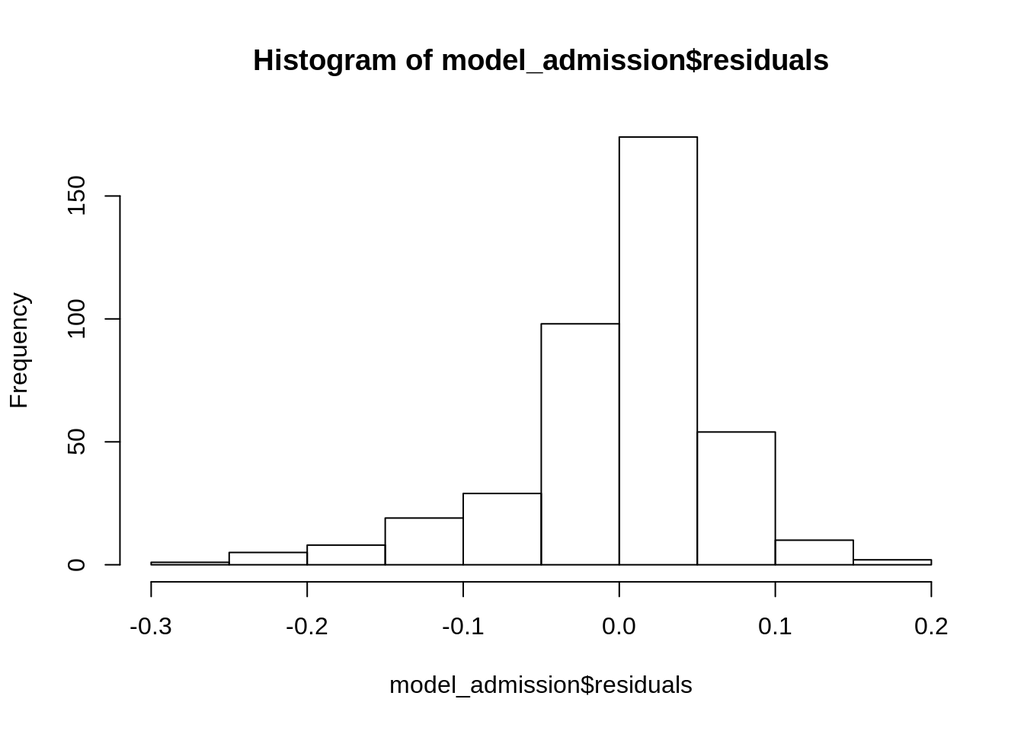

```r
hist(model_admission$residuals)
```

```r
shapiro.test(model_admission$residuals)
```

```
##
##  Shapiro-Wilk normality test
##
## data:  model_admission$residuals
## W = 0.91977, p-value = 8.901e-14
```

### Homoscedacity

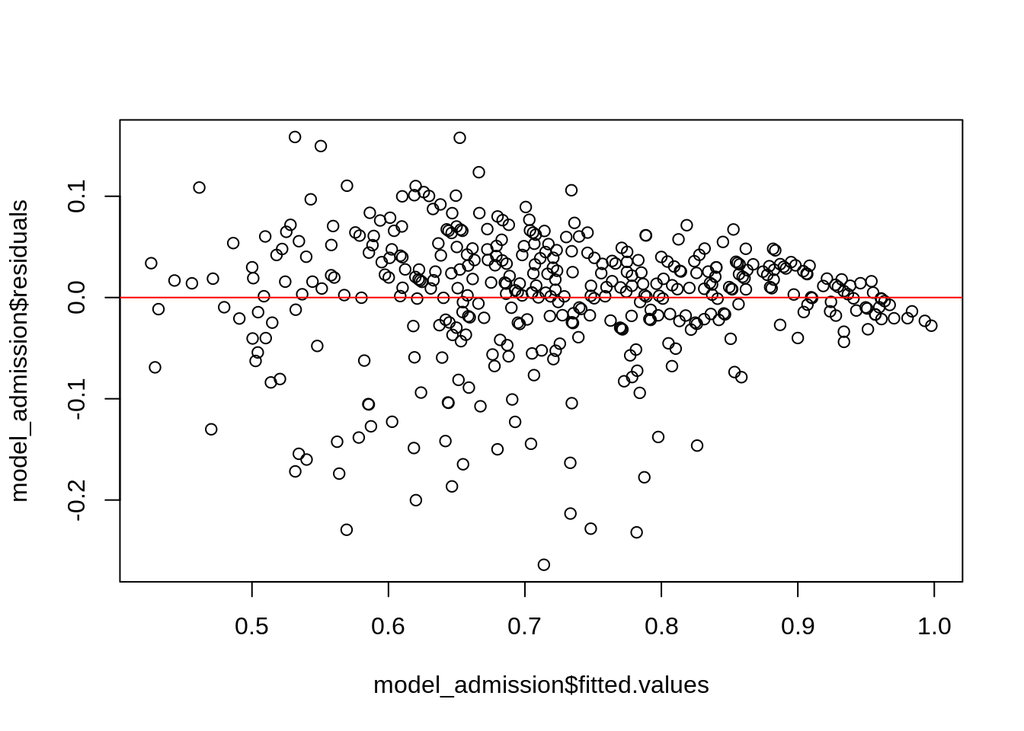

```r
plot(model_admission$fitted.values, model_admission$residuals)
abline(h = 0, col = "red")
```

```r
bptest(model_admission)
```

```
##
##  studentized Breusch-Pagan test
##
## data:  model_admission
## BP = 23.863, df = 6, p-value = 0.0005534
```

Based on our bp test, there seemed to be abit of a pattern here, but looking at the graph, I think it’s still acceptable.

### Multicolinearity

```r
vif(model_admission)
```

```
##         gre_score       toefl_score university_rating               lor
##          4.588481          4.222318          2.649239          2.040413
##              cgpa          research
##          5.102055          1.533822
```

### Initial MSE and RMSE with training data

```r
MSE(y_pred = model_admission$fitted.values, y_true = admission_train$chance_of_admit)
```

```
## [1] 0.003990485
```

```r
RMSE(y_pred = model_admission$fitted.values, y_true = admission_train$chance_of_admit)
```

```
## [1] 0.06317029
```

# PREDICTION

Using the model I’ve built, I will try to test it with the `admission_test` dataset that we’ve split before.

```r
admission_test$chance_admit_predict <- round(predict(object = model_admission, newdata = admission_test),2)
```

### MSE and RMSE value with test data

```r
MSE(y_pred = admission_test$chance_admit_predict, y_true = admission_test$chance_of_admit)
```

```
## [1] 0.003992875
```

```r
RMSE(y_pred = admission_test$chance_admit_predict, y_true = admission_test$chance_of_admit)
```

```
## [1] 0.0631892
```

# CONCLUSION

Considering that our range of data is between `0.34` and `0.97`, I think my model have achieved a pretty good prediction result with average error value of `0.063`.

# CREDITS

The data is kindly provided by : Mohan S Acharya, Asfia Armaan, Aneeta S Antony : A Comparison of Regression Models for Prediction of Graduate Admissions, IEEE International Conference on Computational Intelligence in Data Science 2019